# Part II - (Prosper Loan Analysis Presentation)

## by (Yusuf Sanni)

## Investigation Overview

> . The aim of this presentation is to show how some certain variables like employment status,income range and loan term influence borrowers, especially as regards the loan amount and the monthly repayments. 2 of the key insights I selected had to do with employment status and income range. I believed that these particular variables would be key in defining how borrowers are selected and how they repay their loans.

## Dataset Overview

> The data was provided by Udacity and was gotten from Prosper Loan. This data set contains 113,937 loans with 81 variables on each loan, including loan amount, interest rate, current loan status, borrower income, and many others. The analysis in this part would be structured to provide simple univariate relationships to multivariate relationships, this research would provide answers to questions like whether the monthly loan payment has a correlation or any relationship between loan original,amount, what is the spread of lterm of loan in loan status, identifying the frequency of the categorical variables; Term of loan, borrower's employment status, year of loan, and loan status, are there differences between loans depending on how the loan term large the original loan amount was.

## Distribution of Income Range

> It can be seen from the plot below that the income range most borrowers fall within is 25,000 - 49,999 and 50,000 - 74,999. In other words, the number for each range respectively is 32,192 and 31,050. This gives an indication as regards the prominent income range of the borrowers

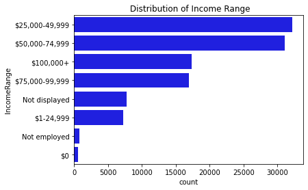

## Distribution of Loan Terms

> It can be seen from the plot below that most of the loans are medium term loans. Medium term loans account for 87778 of all borrowers' loans. This shows the type of loans that appeals more to borrowers .

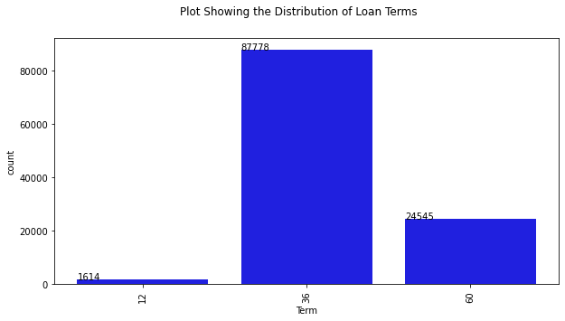

## Distribution of Prosper Score and Loan Terms.

> From the clustered bar chart below, it would seem that medium term loans are in the highest demand, irrespective of the Prosper Score. It depicts that irrespective of the level of risk a borrower poses, borrowers seem more inclined towards medium term loans.

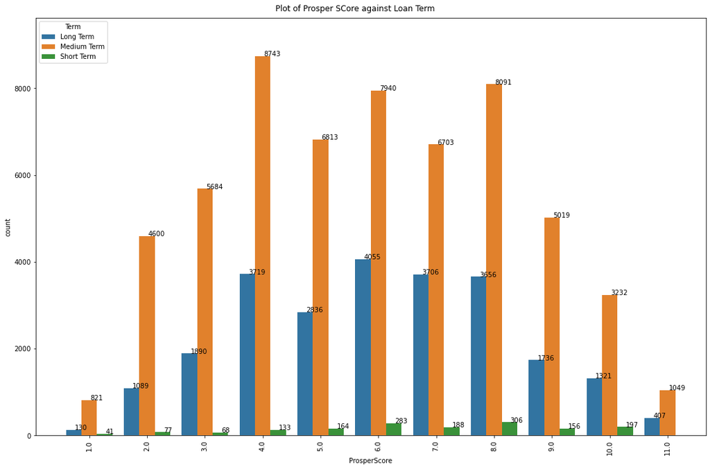

## Distribution of Monthly Loan Payments Against Loan Amount with Loan Terms

[figure not shown]